# R package `jmseq`: fitting joint models of longitudinal and time to event data by sequential Bayesian updating

Paul McKeigue

Joint modelling of longitudinal and time to event data can be efficiently implemented by sequential Bayesian updating. I describe the theory of this approach in a paper now under peer review: "Fitting joint models of longitudinal observations and time to event by sequential Bayesian updating".

This vignette demonstrates an approximate two-step procedure, in which a linear Gaussian state space model is fitted to the longitudinal data, latent states at the start of each person-time interval are sampled from the forward updates generated by the Kalman filter, and these latent state values are plugged into a Poisson regression model for the event status at the end of each person-time interval. Work is in progress to develop a one-step procedure. The R code in this tutorial can be used as a template for analysis of any dataset with longitudinal measurements of biomarkers (transformed to have an approximately gaussian distribution) and time to event.

First we load required R packages including `jmseq`, and compile the Stan script.

```r
library(data.table)
library(survival)
library(jmseq)

source("../R/jmseqfunctions.R") # used during development to load latest versions of functions before updating the jmseq package

poissonglm.model <- rstan::stan_model(file="../stan/poissonglm.stan", verbose=TRUE)
```

```
#>
#> TRANSLATING MODEL 'poissonglm' FROM Stan CODE TO C++ CODE NOW.
#> successful in parsing the Stan model 'poissonglm'.
```

# Dataset

The data are provided in two tables. `dataLong` contains the biomarker data, with one row per person per date of observation. The character vector `biomarkers` specifies the names of the biomarker variables, and `timeinvar.long` specifies the names of the time-invariant covariates in the longitudinal submodel. `dataSurv` contains the time to censoring with an indicator for event status (0 or 1) at the time of censoring, and `timeinvar.surv` specifies the names of the time-invariant covariates in the event submodel.

For joint modelling, we reformat the dataset as person-time intervals. Person-time intervals longer than `max.interval` are split using the function `split.SurvLong`. We set `max.interval` to 0.25 years as a compromise between accuracy and computation time. The new intervals have missing values for the biomarker observations, and event status set to 0.

```r
data(pbc, package="jmseq")
list2env(pbc, envir=environment())
```

```
#> <environment: R_GlobalEnv>
```

```r
nfolds <- 5
landmark.time <- 5
maxtime <- 15
set.seed <- 2345
max.interval <- 0.25

library(survival)

surv.split <- split.SurvLong(pbc$dataSurv, pbc$dataLong, max.interval=max.interval)
keep.long <- c("id", "Time", "tstop", timeinvar.long, biomarkers)
keep.surv <- c("id", timeinvar.surv, "Time", "tstop", "event")
dataLong <- surv.split[, ..keep.long]
dataSurv <- surv.split[, ..keep.surv]
```

# Models for the longitudinal data

We shall compare two models for the biomarker data: a linear mixed model with random slopes, and a more general model linear Gaussian state space model with random slopes, autoregressive drift and diffusion (Wiener process).

```r
## create list of models
models.list <- listmodels(biomarkers, timeinvar.long)[c(1, 5)]
```

## Fitting the longitudinal model

Next we use `ctsem` to fit these models to the full dataset. The function `jmseq::ctstanfit.fold()` is a wrapper for `ctsem::ctStanFit()`

```r
lmmonly.fit <- ctstanfit.fold(train.dataset=dataLong, ctmodel=models.list[[1]])
lmmdriftdiff.fit <- ctstanfit.fold(train.dataset=dataLong, ctmodel=models.list[[2]])
```

## Comparison of longitudinal models

Comparing the fit of the full Gaussian state space model to the linear mixed model shows that the full model has higher log-likelihood and lower AIC. This is typical of clinical data with long follow-up times.

```r
s1 <- summary(lmmonly.fit)
s2 <- summary(lmmdriftdiff.fit)

compare <- rbind(data.frame(model="LMM only", loglik=s1$loglik, npars=s1$npars, aic=s1$aic),
                 data.frame(model="LMM + drift + diff", loglik=s2$loglik, npars=s2$npars, aic=s2$aic))

knitr::kable(data.table(model=names(models.list), compare))
```

| model | model | loglik | npars | aic |
| --- | --- | --- | --- | --- |
| model.lmm | LMM only | -3482.352 | 28 | 7020.705 |
| model.lmmdriftdiff | LMM + drift + diff | -3374.662 | 49 | 6847.324 |

# Generating forward updates of latent state values with the Kalman filter

From the fitted models we can generate forward updates of the predicted latent state trajectories for each individual. The `ctsem::ctKalman()` function has an option to plot these trajectories. The plots below show the predicted trajectories for the first five individuals in the dataset. Each time a new observation arrives, the predicted trajectories are updated: so the curve may jump to a new position.

## Example with five individuals

```
#> Computing state estimates..
#> Computing quantities for 1 samples...
```

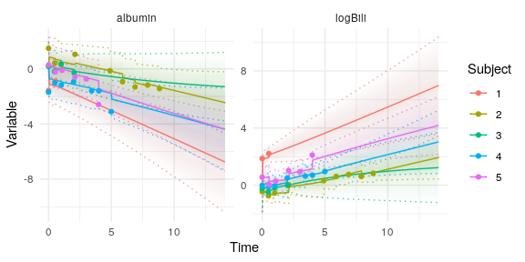

```r
## plot imputed values for first five individuals
ctsem::ctKalman(fit=lmmdriftdiff.fit, kalmanvec=c("y", "yprior"),
         subjects=1:5, plot=TRUE)
```

# Fitting the event model

To fit the event submodel, we need to generate imputed values of the latent state variables from the forward updates of the state probabilities computed by the Kalman filter.

The function `jmseq::kalmanwide` calls `ctsem::ctKalman()` to generate the imputed values, and reshapes the table of imputed values from long to wide format: one observation per person-time interval.

```r
latent.updates <- kalmanwide(lmmdriftdiff.fit, subjects="all",
                             timestep="asdata",
                             timerange=c(0, maxtime))
```

## Using the imputed latent state values in a Poisson regression model for event status

These latent state values at the start of the interval are plugged into a Poisson regression model for the event status at the end of each interval.

We have three options for fitting the Poisson regression model: the R function `glm`, ('stan=FALSE') to maximize the likelihood, using Stan to find the posterior mode ('stan=TRUE, vb=FALSE'), or a variational Bayes algorithm with Stan ('stan=TRUE, vb=TRUE') which generates samples from the approximate posterior. The Stan options are included as a first step in development of a one-step joint model, in which information from the event indicators feeds into the longitudinal submodel. The variational Bayes algorithm minimizes the Kullback-Leibler divergence between the true posterior and the approximating distribution my maximizing the "evidence lower bound" (ELBO).

```r
## fit Poisson model to training datasets for each fold within each ctsem model
poisson.glm.beta <- fit.poissontsplit(latent.updates,
                                      dataSurv,
                                      timeinvar.surv, biomarkers, splines=FALSE,
                                      stan=TRUE, vb=TRUE)

#if(colnames(poisson.glm.beta)[1]=="Estimate") {
coeffs <- poisson.glm.beta
#}
```

A table of regression coefficients for the fitted Poisson regression model is shown below. Mortality is associated with high predicted log bilirubin and with low predicted serum albumin.

```r
knitr::kable(coeffs,
             row.names=TRUE,
             digits=c(3, 3, 3, 3),
             caption="Poisson time-splitting model fitted to latent biomarker values imputed by Kalman filter from linear Gaussian state space model")
```

Poisson time-splitting model fitted to latent biomarker values imputed by Kalman filter from linear Gaussian state space model

|  | mean.chain:1 | sd.chain:1 | 2.5%.chain:1 | 97.5%.chain:1 |
| --- | --- | --- | --- | --- |
| (Intercept) | -3.666 | 0.095 | -3.864 | -3.478 |
| tstart | -0.093 | 0.027 | -0.144 | -0.040 |
| sex | -0.066 | 0.073 | -0.207 | 0.070 |
| agebaseline | 0.280 | 0.086 | 0.107 | 0.449 |
| trtD-penicil | -0.145 | 0.157 | -0.447 | 0.169 |
| logBili | 0.957 | 0.094 | 0.779 | 1.143 |
| albumin | -1.345 | 0.151 | -1.637 | -1.048 |

# Cross-validation

## Test-training split

For cross-validation of the prediction of events, we split the dataset into test and training folds. This tutorial uses 5 folds but the user can set `nfolds` to a lower value to save computation, or to a higher value for more accuracy. .  
Each test fold contains all observations after the landmark time (5 years) on the individuals in that test fold. Each training fold contains all observations on those individuals who are not in the corresponding test fold. For those individuals who are in the corresponding test fold, the biomarker observations after the landmark time are set to missing.

```r
ids.tosample <- unique(dataSurv[Time > landmark.time, id]) # & dataSurv$Time < max(dataSurv$Time))
ids.permuted <- base::sample(ids.tosample)
## test-train split for nfold cross-validation
folds <- cut(1:length(ids.permuted), breaks=nfolds, labels=FALSE)

## create list of ids in each testfolds
ids.test <- vector("list", nfolds)
for(i in 1:nfolds) {
    ids.test[[i]] <- ids.permuted[folds==i]
}

## create training datasets
train.datasets <- vector("list", nfolds)
for(i in 1:nfolds) { # loop over folds
    train.datasets[[i]] <- vector("list", 3)
    names(train.datasets[[i]]) <- c("Surv", "Long", "ids.test")
    train.datasets[[i]]$Surv <- trainsplit.surv(ids.test=ids.test[[i]],
                                                dataSurv=dataSurv,
                                                landmark.time=landmark.time)
    train.datasets[[i]]$Long <- trainsplit.long(ids.test[[i]],
                                                dataLong=dataLong, landmark.time,
                                                biomarkers)
    train.datasets[[i]]$ids.test <- ids.test[[i]]
}
```

## Fitting the longitudinal models to training folds

Next we run `ctsem` to fit each of these models to each training fold. In each training fold, the forward updates continue to the end of the follow-up period including the person-time intervals in the test fold, where the biomarker observations have been dropped. The fitted models are saved in `fitted.list`. This step is parallelised over folds using `parallel::parLapply`.

```r
## mclapply and foreach %dopar% fail -- child processes cannot open sockets

start <- Sys.time()
cl <- parallel::makePSOCKcluster(8)
fitted.list <- vector("list", length(models.list))
names(fitted.list) <- names(models.list)
cat("Looping over ctsem models to fit to training datasets ...\n")
for(m in 1:length(models.list)) { # loop over models
    fitted.list[[m]] <-
     #lapply(X=train.datasets, FUN=ctstanfit.fold, ctmodel=models.list[[m]])
     parallel::parLapply(cl, X=train.datasets, fun=ctstanfit.fold, ctmodel=models.list[[m]])
     gc()
    names(fitted.list[[m]]) <- paste0("fold", 1:nfolds)
}
parallel::stopCluster(cl)
cat("done, time ", difftime(Sys.time(), start, "mins"), "minutes\n")
```

## Imputing latent state values over all person-time intervals

Next we generate imputed values of the latent state variables from the forward updates of the state probabilities computed by the Kalman filter. In each training fold, the forward updates continue to the end of the follow-up period including the person-time intervals in the test fold, where any biomarker observations have been set to missing. This step is parallelised over folds using `parallel::mcmapply`.

The list of fitted models is of length 2, and each element is a list of fitted models for each training fold.

```r
## generate imputations from each training fold within each ctsem model
## we have to run the imputations up to maxtime for everyone, then censor later
start <- Sys.time()
cat("Looping over ctsem models to generate imputations from Kalman filter ...\n")
kalwide.list <- vector("list", length(models.list))
names(kalwide.list) <- names(models.list)
for(m in 1:length(models.list)) { # loop over models
    kalwide.list[[m]] <- parallel::mcmapply(FUN=kalmanwide,
                                fitted.list[[m]],
                                MoreArgs=list(timestep="asdata",
                                              timerange=c(0, maxtime)),
                                SIMPLIFY=FALSE)
}
cat("done, time ",  difftime(Sys.time(), start, "mins"), "minutes\n")
imputed.test <- kalwide.list[[2]][[1]][Subject %in% ids.test[[1]]]
```

To illustrate the predictions, we plot the predicted trajectories for the first 5 individuals in the test dataset from the first fold in the model 2 (full Gaussian state space model). All biomarker observations after 5 years have been set to missing, so the curves do not jump after that time.

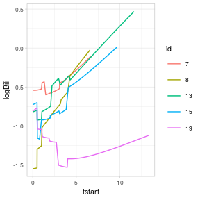

```r
imputed.first5ids <- unique(imputed.test$id)[1:5]
imputed.test <- imputed.test[id %in% imputed.first5ids]
imputed.test[, id := factor(id)]
library(ggplot2)
ggplot(data=imputed.test, aes(x=tstart, y=logBili, color=id)) + geom_line()
```

```r
## no need to censor imputations at censoring time for each individual.
## test dataset: retain rows with ids in test fold and imputed values after landmark.time.
## train dataset: drop rows after landmark time for those in test fold
kalwide.test.list <- vector("list", length(models.list))
kalwide.train.list <- vector("list", length(models.list))
for(m in 1:length(models.list)) { # loop over models
    kalwide.test.list[[m]] <- mapply(FUN=function(k, ids.keep)
        k[id %in% ids.keep & tstart > landmark.time],
        kalwide.list[[m]],
        ids.test,
        SIMPLIFY=FALSE)

    kalwide.train.list[[m]] <- mapply(FUN=function(k, ids.drop)
        k[!(id %in% ids.drop & tstart > landmark.time)],
        kalwide.list[[m]],
        ids.test,
        SIMPLIFY=FALSE)
}
```

## Training a Poisson regression model for event status on imputed latent states

The latent state values at the start of the interval are plugged into a Poisson regression model for the event status at the end of each interval.

```r
## fit Poisson model to training datasets for each fold within each ctsem model
coeffs.train <- vector("list", length(models.list))
for(m in 1:length(models.list)) { # loop over models
    coeffs.train[m] <- vector("list", length(nfolds))
    for(fold in 1:nfolds) { # loop over trainig folds
        coeffs.train[[m]][[fold]] <- fit.poissontsplit(kalwide.train.list[[m]][[fold]],
                                                   train.datasets[[fold]]$Surv,
                                                   timeinvar.surv, biomarkers, splines=FALSE,
                                                   stan=FALSE)
    }
}
names(coeffs.train) <- names(models.list)
```

## Prediction of event status on test folds

The final step in the cross-validation is to use the Poisson regression model fitted to each training fold to generate predictions of event status on the test folds from the forward predictions of the latent states. Predictive performance is evaluated by concatenating observed and predicted event status over all test folds.

```r
## generate predictions on test folds
## elements of testdata.list are concatenations of all test folds
testdata.list <- vector("list", length(models.list))
names(testdata.list) <- names(models.list)
for(m in 1:length(models.list)) { # loop over models
    ## vectorize over test olds: args before MoreArgs are lists of folds
    testdata.model.list <- mapply(FUN=predict.testdata,
                                  beta=coeffs.train[[m]],
                                  imputed.dt=kalwide.test.list[[m]],
                                  MoreArgs=list(dataSurv=dataSurv,
                                                timeinvar.surv=timeinvar.surv,
                                                biomarkers=biomarkers,
                                                landmark.time=landmark.time),
                                  SIMPLIFY=FALSE)
    testdata.list[[m]] <- data.table::rbindlist(testdata.model.list)
}

## generate summary table of predictive performance
predict.table <- NULL
for(i in 1:length(testdata.list)) { # loop over models
    stats <- tabulate.predictions(testdata.list[[i]])
    predict.table <- rbind(predict.table, stats)
}
predict.table <- data.table(Model=names(testdata.list), predict.table)
predict.table[, Predicted := as.numeric(Predicted)]
predict.table[, `Person-years` := as.numeric(`Person-years`)]
predict.table [, `Log score` := as.numeric(`Log score`)]
predict.table[, `C-statistic` := as.numeric(`C-statistic`)]
```

The cross-validated predictive performance of the event submodels is summarised in the table below. The evidence that one model is better than another can be assessed by the differences in test log-likelihood (known as the logarithmic score). This however doesn't tell us anything about the size of the difference in predictive performance between models. For this we can compare the C-statistic values, though it is more meaningful to compare the expected information for discrimination as described [elsewhere](https://pubmed.ncbi.nlm.nih.gov/29978758/). For the C-statistic to be valid, we ignore any censoring before the end of the last time interval in each individual and compare the observed event status with the probability of failure before the end of each person-time interval (obtained from the predictive model). See [this page](http://www.homepages.ed.ac.uk/pmckeigu/stats/survival.html) for an explanation of why this is correct. The total person-years of follow-up after 5 years (on which the test dataset is constructed) is thus greater than the true value of 623 person-years. This discrepancy can be made arbitrarily small by splitting the follow-up time into short person-time intervals, but this increases the computation time.

```r
knitr::kable(predict.table)
```

| Model | Observed | Predicted | Person-years | Log score | C-statistic |
| --- | --- | --- | --- | --- | --- |
| model.lmm | 51 | 75.47768 | 707.2652 | -295.2517 | 0.7890386 |
| model.lmmdriftdiff | 51 | 65.40435 | 707.2652 | -248.4624 | 0.8070996 |

The full Gaussian state space modelwith drift and diffusion has better predictive performance than the linear mixed model (test log-likelihood higher by about 50 natural log units) and the C-statistic is also higher.